# HW2 Vibe coding example2 問いかけと出力記録

Author

Published

October 07, 2026, 21:10 +0900

# Meta prompt

Below is what I asked you in the terminal.

> I am a student who is analyzing data related to education. Find HW2_VibeCoding.qmd in this folder. Read the Procedure. Respond to my Instructions and render the file. I will update the file each time I receive your outputs written in the file.

# Procedure

- I will add “Instructions” as you provide “Outputs.”
- You will add outputs right after each instruction. Also add “X+1th query” subsection, “Instructions”, and “Outputs” when you respond to the X-th query.
- The user executes codes either in quarto, rmarkdown, or litedown.
- When you provide codes, they must be either in R or Python. R is the most preferred language. Use Python only if you cannot get the task done with R.
  - Find how litedown and rmarkdown can run python using a library, but avert the use of python if possible
- Codes must be accompanied with comment lines understandable to a novice coder.
- Assume no libraries are installed. Write codes that:
  - Prompt the user to accept installation, or,
  - Show how to install mannually.
- Do not use pipe operators.
- Use data.table rather than dplyr etc.
- Code blocks must not result in horizontal scroll bars. Use linebreaks.
- Produce pastable code blocks with line numbers shown.
  - In quarto, use line hilighting.
- Use a Tufte style css. Find the right main text width that is best for viewing.
- When you download data, store locally so the user does not have to download them again. Make sure you check before downloading if the data are available locally.
- Outputs must be succinct. Do not provide any analytical comments. I will do the interpretations. Provide only data related information that is useful in interpreting outputs, and the reason of your choices in creating outputs.

# Instructions and outputs

## 1st query

### Instructions

- I am trying to estimate the mean schooling years of humans.
- This is an average of schooling years of all world population at each point of time.
- Final output is a line plot with a line connecting each points, showing time series changes.
- Lines must be accompanied with 95% confidence intervals, expressed as shades.
- I also want a regional breakdown of estimates and their plots, a group of lines in a single figure.
- X axis is calendar years, Y axis is schooling years. Use colour blind aware colour schemes, as in viridis. Use a discrete scale.
- Find most suitable variables from WB data, UNICEF, DHS or any other authoritative sources.

### Outputs

Variables

| Source | Variable | Unit of observation | Years | Countries | Ages |
| --- | --- | --- | --- | --- | --- |
| Barro-Lee v3 | `yr_sch`, `pop` | country × 10-year age group | 1950–2015, every 5 years | 146 | 25–64 |
| UNDP HDR 2023/24 | `mys_YYYY`, `pop_total_YYYY` | country | 1990–2022, annual | 195 | 25+ |

Reasons for choices

- Variable: mean years of schooling of adults. Barro-Lee and UNDP are the two producers. WB WDI and UNICEF republish them. DHS reports medians for surveyed countries only, so it cannot give a world mean.
- Two sources: Barro-Lee covers the longest span (from 1950). UNDP is annual and more recent (to 2022).
- Ages: 25+ is the usual definition (most people have finished school by 25). Barro-Lee’s file stops at age 64, so it uses 25–64.
- World and regional means: population-weighted means of country values. In Barro-Lee, each country’s value is first a population-weighted mean over its four age groups.
- 95% confidence intervals: neither source publishes standard errors. The shades are bootstrap intervals: countries are redrawn with replacement 1,000 times (within each region for the regional figures) and the weighted mean is recomputed each time. The 2.5% and 97.5% values of the 1,000 means form the interval. The interval reflects variation across countries, not measurement error in each country’s figure.
- Regions are those defined by each source. They differ: Barro-Lee has 7 regions including “Advanced Economies”; UNDP has 6 developing regions. The 44 countries with no UNDP region are grouped as “No UNDP region”. So each source has its own regional figure.
- Missing values: UNDP lacks 1990 values for 43 countries; a country enters a year’s mean only when it has a value for that year. Barro-Lee has none missing.
- Colours: viridis discrete scale (colour-blind safe).
- Data files are downloaded once into this folder and read from there afterwards.

```r
# Packages used below:
#  data.table: data handling
#  ggplot2:    figures
pkgs <- c("data.table", "ggplot2")
have <- rownames(installed.packages())
miss <- pkgs[!pkgs %in% have]
if (length(miss) > 0) {
  if (interactive()) {
    # Ask before installing anything
    ans <- readline(paste0(
      "Install ",
      paste(miss, collapse = ", "),
      "? [y/n] "))
    if (tolower(ans) == "y") {
      install.packages(miss)
    }
  } else {
    # While rendering, R cannot ask.
    # Stop and show the command to type
    # in the R console.
    stop("Please run in the R console: ",
         "install.packages(c(\"",
         paste(miss, collapse = "\", \""),
         "\"))")
  }
}
library(data.table)
library(ggplot2)
```

```r
# Download each file only if it is not
# already in this folder.
bl_file <- "BL_v3_MF.csv"
bl_url <- paste0(
  "https://barrolee.github.io/",
  "BarroLeeDataSet/BLData/", bl_file)
if (!file.exists(bl_file)) {
  download.file(bl_url, bl_file,
                mode = "wb")
}
un_file <- paste0(
  "HDR23-24_Composite_indices_",
  "complete_time_series.csv")
un_url <- paste0(
  "https://hdr.undp.org/sites/default/",
  "files/2023-24_HDR/", un_file)
if (!file.exists(un_file)) {
  download.file(un_url, un_file,
                mode = "wb")
}
# Read both files as data.tables
bl <- fread(bl_file)
un <- fread(un_file)
```

```r
# Population-weighted mean for each year,
# with a 95% bootstrap interval.
# Input d: one row per country x year,
#   with columns country, year,
#   mys (schooling years), pop.
boot_mean <- function(d, B = 1000) {
  # Tables: rows = countries,
  #         columns = years
  m <- dcast(d, country ~ year,
             value.var = "mys")
  w <- dcast(d, country ~ year,
             value.var = "pop")
  yrs <- as.integer(names(m)[-1])
  m <- as.matrix(m[, -1])
  w <- as.matrix(w[, -1])
  # A missing value gets zero weight
  w[is.na(m) | is.na(w)] <- 0
  m[is.na(m)] <- 0
  # Weighted mean of the actual data
  est <- colSums(m * w) / colSums(w)
  # Redraw countries B times
  n <- nrow(m)
  draws <- matrix(NA_real_, B,
                  ncol(m))
  for (b in 1:B) {
    i <- sample(n, n, replace = TRUE)
    mi <- m[i, , drop = FALSE]
    wi <- w[i, , drop = FALSE]
    draws[b, ] <- colSums(mi * wi) /
      colSums(wi)
  }
  # 2.5% and 97.5% of the B means
  lo <- apply(draws, 2, quantile,
              probs = 0.025,
              na.rm = TRUE)
  hi <- apply(draws, 2, quantile,
              probs = 0.975,
              na.rm = TRUE)
  data.table(year = yrs, mys = est,
             lo = lo, hi = hi)
}
# Fix the random draws so the
# intervals are the same every run
set.seed(20261008)
```

```r
# Keep adults: age groups 25-34 to 55-64
bla <- bl[agefrom >= 25]
# One value per country x year:
# population-weighted over age groups
blc <- bla[, .(
  mys = sum(yr_sch * pop) / sum(pop),
  pop = sum(pop)),
  by = .(country, year,
         region = region_code)]
# World: all countries together
bl_wld <- boot_mean(blc)
# Regions: one run per region
bl_reg <- blc[, boot_mean(.SD),
              by = region]
```

```r
# Country rows only (UNDP's own
# aggregates have codes starting "ZZ")
unc <- un[!grepl("^ZZ", iso3)]
# Names of the year columns
mys_cols <- grep("^mys_[0-9]{4}$",
                 names(unc), value = TRUE)
pop_cols <- grep("^pop_total_[0-9]{4}$",
                 names(unc), value = TRUE)
# Wide (one column per year) to long
# (one row per country x year)
m1 <- melt(unc,
           id.vars = c("country",
                       "region"),
           measure.vars = mys_cols,
           variable.name = "year",
           value.name = "mys")
m1[, year := as.integer(
  sub("mys_", "", year))]
p1 <- melt(unc,
           id.vars = "country",
           measure.vars = pop_cols,
           variable.name = "year",
           value.name = "pop")
p1[, year := as.integer(
  sub("pop_total_", "", year))]
unl <- merge(m1, p1,
             by = c("country", "year"))
# Region codes to names. Countries with
# a blank code get "No UNDP region".
reg_names <- c(
  AS  = "Arab States",
  EAP = "East Asia and the Pacific",
  ECA = "Europe and Central Asia",
  LAC = "Latin America and the Caribbean",
  SA  = "South Asia",
  SSA = "Sub-Saharan Africa")
unl[, region := reg_names[region]]
unl[is.na(region),
    region := "No UNDP region"]
un_wld <- boot_mean(unl)
un_reg <- unl[, boot_mean(.SD),
              by = region]
```

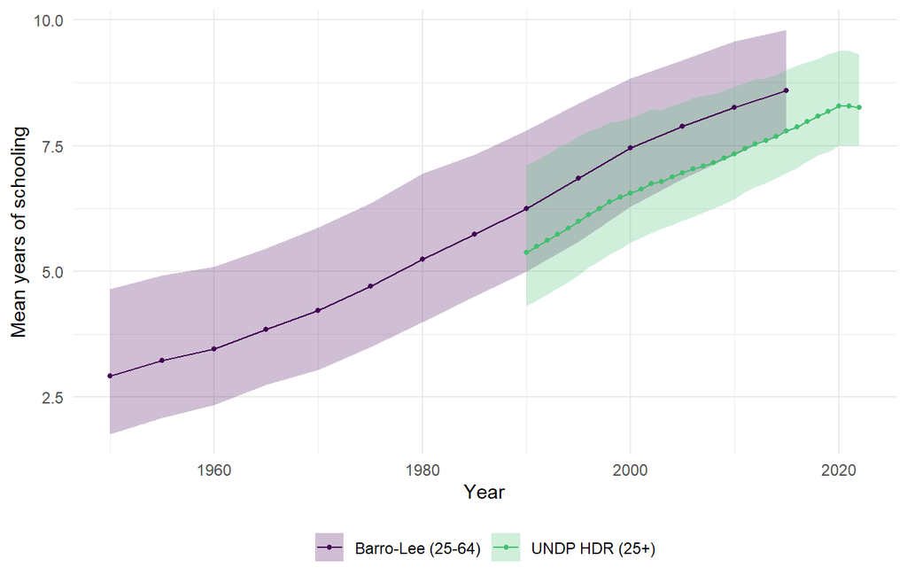

Figure 1

```r
# World mean from both sources in one
# figure. Shades = 95% intervals.
bl_wld[, source := "Barro-Lee (25-64)"]
un_wld[, source := "UNDP HDR (25+)"]
wld <- rbind(bl_wld, un_wld)
ggplot(wld, aes(x = year, y = mys,
                colour = source,
                fill = source)) +
  geom_ribbon(aes(ymin = lo,
                  ymax = hi),
              alpha = 0.25,
              colour = NA) +
  geom_line() +
  geom_point(size = 1) +
  scale_colour_viridis_d(end = 0.7) +
  scale_fill_viridis_d(end = 0.7) +
  labs(x = "Year",
       y = "Mean years of schooling",
       colour = NULL, fill = NULL) +
  theme_minimal() +
  theme(legend.position = "bottom")
```

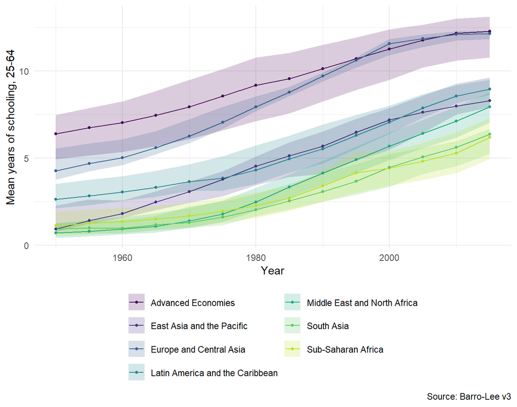

Figure 2

```r
# Barro-Lee regions, one line each
ggplot(bl_reg, aes(x = year, y = mys,
                   colour = region,
                   fill = region)) +
  geom_ribbon(aes(ymin = lo,
                  ymax = hi),
              alpha = 0.2,
              colour = NA) +
  geom_line() +
  geom_point(size = 1) +
  scale_colour_viridis_d(end = 0.9) +
  scale_fill_viridis_d(end = 0.9) +
  labs(x = "Year",
       y = "Mean years of schooling, 25-64",
       colour = NULL, fill = NULL,
       caption = "Source: Barro-Lee v3") +
  theme_minimal() +
  theme(legend.position = "bottom") +
  guides(colour = guide_legend(ncol = 2),
         fill = guide_legend(ncol = 2))
```

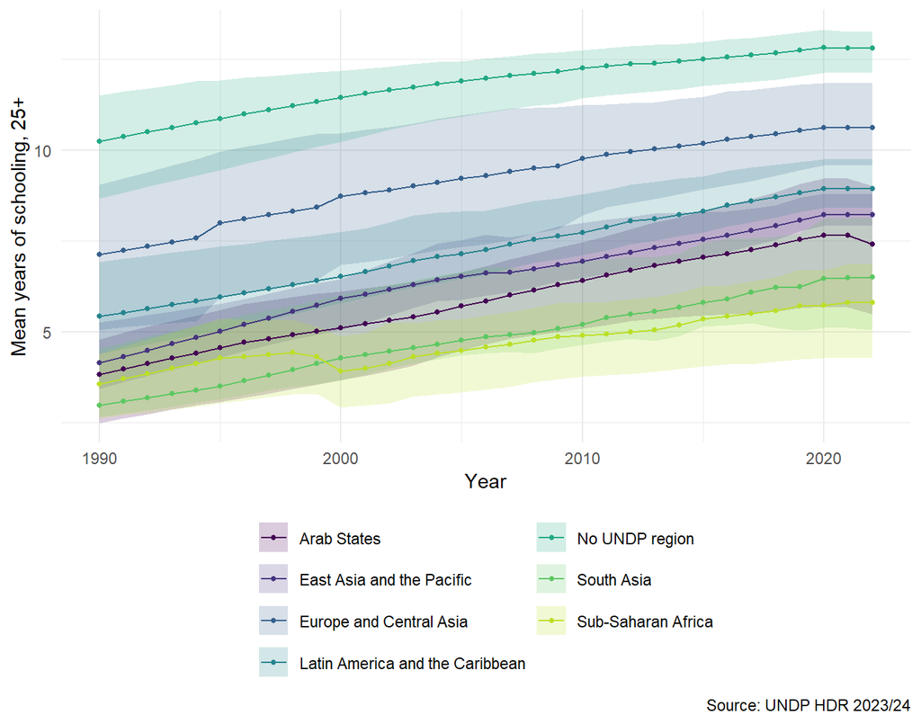

Figure 3

```r
# UNDP regions, one line each
ggplot(un_reg, aes(x = year, y = mys,
                   colour = region,
                   fill = region)) +
  geom_ribbon(aes(ymin = lo,
                  ymax = hi),
              alpha = 0.2,
              colour = NA) +
  geom_line() +
  geom_point(size = 1) +
  scale_colour_viridis_d(end = 0.9) +
  scale_fill_viridis_d(end = 0.9) +
  labs(x = "Year",
       y = "Mean years of schooling, 25+",
       colour = NULL, fill = NULL,
       caption = "Source: UNDP HDR 2023/24") +
  theme_minimal() +
  theme(legend.position = "bottom") +
  guides(colour = guide_legend(ncol = 2),
         fill = guide_legend(ncol = 2))
```

Data notes

```r
# Counts that describe the data used
n_un <- unl[!is.na(mys),
            .(countries = uniqueN(country)),
            by = year]
notes <- data.table(
  item = c(
    "Barro-Lee countries",
    "Barro-Lee years",
    "Barro-Lee regions",
    "Barro-Lee missing yr_sch or pop",
    "UNDP countries",
    "UNDP countries with mys, 1990",
    "UNDP countries with mys, 2022",
    "UNDP years",
    "UNDP regions (incl. No UNDP region)",
    "Bootstrap draws"),
  value = c(
    uniqueN(blc$country),
    paste(range(blc$year),
          collapse = "-"),
    uniqueN(blc$region),
    sum(is.na(bla$yr_sch) |
          is.na(bla$pop)),
    uniqueN(unl$country),
    n_un[year == 1990, countries],
    n_un[year == 2022, countries],
    paste(range(unl$year),
          collapse = "-"),
    uniqueN(unl$region),
    1000))
notes
```

```
                                   item     value
                                 <char>    <char>
 1:                 Barro-Lee countries       146
 2:                     Barro-Lee years 1950-2015
 3:                   Barro-Lee regions         7
 4:     Barro-Lee missing yr_sch or pop         0
 5:                      UNDP countries       195
 6:       UNDP countries with mys, 1990       152
 7:       UNDP countries with mys, 2022       193
 8:                          UNDP years 1990-2022
 9: UNDP regions (incl. No UNDP region)         7
10:                     Bootstrap draws      1000
```

## 2nd query